# Workshop Week 6

Author

Affiliation

STAT5003

School of Mathematics and Statistics

# 1 Learning Outcomes

**Learning Outcomes**

- Understand and apply different algorithms for classification tasks:
  1. **Logistics regression**: Use `glm` for classification tasks
  2. **Linear Discriminant Analysis (LDA)**: Use `lda` for classification
  3. **k-nearest neighbours (kNN)**: Use `knn` for classification
  4. **Utilize Support Vector Machines (SVM)**: Use `svm` for classification

# 2 Loading Packages

At the start of your R workshop, load all necessary packages to ensure a smooth session. Here’s an example.

```r
library(dplyr)      # Data manipulation
library(tidyr)      # Tidying data
library(tidyverse)  # Data science packages
library(ggplot2)    # Data visualization
library(here)       # File paths
# install.packages("rsample")
library(rsample)    # alternative to caret package to split between the training and test sets
# install.packages("ggthemes")
library(ggthemes)   # to produce color-blind friendly graphs
```

## 2.1 Workshop preparation

This week, we will apply four classifiers using the `PimaIndiansDiabetes` dataset, which is included in the `mlbench` package. First, you will need to install the `mlbench` package. To load the data, follow these steps:

**Install and load the dataset**

```r
# Install the mlbench package if you haven't already
#install.packages("mlbench")

# Load the mlbench package
library(mlbench)
# Load the PimaIndiansDiabetes dataset
data(PimaIndiansDiabetes2)
```

**EDA Pima Indians Diabetes Data**

Inspect the `PimaIndiansDiabetes2` and verify its structure. It should have 9 columns, 8 of those being numeric features and a single class label variable. If any missing data is observed, discard it and assign it to an object `complete.pimas`. You may use `?na.omit` or `?drop_na()`.

**For the rest of the workshop, we will use the `complete.pimas`.**

```r
dim(PimaIndiansDiabetes2)
```

```
[1] 768   9
```

```r
str(PimaIndiansDiabetes2)
```

```
'data.frame':   768 obs. of  9 variables:
 $ pregnant: num  6 1 8 1 0 5 3 10 2 8 ...
 $ glucose : num  148 85 183 89 137 116 78 115 197 125 ...
 $ pressure: num  72 66 64 66 40 74 50 NA 70 96 ...
 $ triceps : num  35 29 NA 23 35 NA 32 NA 45 NA ...
 $ insulin : num  NA NA NA 94 168 NA 88 NA 543 NA ...
 $ mass    : num  33.6 26.6 23.3 28.1 43.1 25.6 31 35.3 30.5 NA ...
 $ pedigree: num  0.627 0.351 0.672 0.167 2.288 ...
 $ age     : num  50 31 32 21 33 30 26 29 53 54 ...
 $ diabetes: Factor w/ 2 levels "neg","pos": 2 1 2 1 2 1 2 1 2 2 ...
```

```r
## using base R functions
## Discard any NA observations
complete.pimas <- na.omit(PimaIndiansDiabetes2)

## Verify if all NAs have been removed

# Check if there are any NAs in the dataframe
any(is.na(complete.pimas))
```

```
[1] FALSE
```

```r
# Check for NAs in each column
colSums(is.na(complete.pimas))
```

```
pregnant  glucose pressure  triceps  insulin     mass pedigree      age
       0        0        0        0        0        0        0        0
diabetes
       0
```

```r
## discard any NA obs
complete.pimas <- PimaIndiansDiabetes2 |> drop_na()

## verify if all the NAs have been removed

# Check for NAs in the dataframe using is.na()
complete.pimas |>
  is.na() |>
  any()
```

```
[1] FALSE
```

```r
# Check for NAs in each column using dplyr
complete.pimas |>
  summarise_all(~ sum(is.na(.)))
```

```
  pregnant glucose pressure triceps insulin mass pedigree age diabetes
1        0       0        0       0       0    0        0   0        0
```

## 2.2 Logistic Regression

**Classification**

Use `glm()` to perform logistic regression on `complete.pimas` to classify observations as positive or negative for diabetes.

In particular, determine which of the features seem the most informative to explain the diabetes class.

```r
logit.model <- glm(diabetes ~ ., data = complete.pimas,
                   family = binomial(link = "logit"))
summary(logit.model)
```

```
Call:
glm(formula = diabetes ~ ., family = binomial(link = "logit"),
    data = complete.pimas)

Coefficients:
              Estimate Std. Error z value Pr(>|z|)
(Intercept) -1.004e+01  1.218e+00  -8.246  < 2e-16 ***
pregnant     8.216e-02  5.543e-02   1.482  0.13825
glucose      3.827e-02  5.768e-03   6.635 3.24e-11 ***
pressure    -1.420e-03  1.183e-02  -0.120  0.90446
triceps      1.122e-02  1.708e-02   0.657  0.51128
insulin     -8.253e-04  1.306e-03  -0.632  0.52757
mass         7.054e-02  2.734e-02   2.580  0.00989 **
pedigree     1.141e+00  4.274e-01   2.669  0.00760 **
age          3.395e-02  1.838e-02   1.847  0.06474 .
---
Signif. codes:  0 '***' 0.001 '**' 0.01 '*' 0.05 '.' 0.1 ' ' 1

(Dispersion parameter for binomial family taken to be 1)

    Null deviance: 498.10  on 391  degrees of freedom
Residual deviance: 344.02  on 383  degrees of freedom
AIC: 362.02

Number of Fisher Scoring iterations: 5
```

Based on the p-value, it seems that `glucose` provides the most information explaining diabetes’ status.

```r
library(broom) ## using the broom package to print out tidy model outputs
predictors <- names(complete.pimas)[-9] ## where the last column is the class label

for(i in predictors){
  formula <- as.formula(paste("diabetes~", i))
  model <- glm(formula, family = "binomial", data = complete.pimas)
  print(tidy(model))


}
```

```
# A tibble: 2 × 5
  term        estimate std.error statistic  p.value
  <chr>          <dbl>     <dbl>     <dbl>    <dbl>
1 (Intercept)   -1.28     0.167      -7.71 1.29e-14
2 pregnant       0.167    0.0344      4.84 1.28e- 6
# A tibble: 2 × 5
  term        estimate std.error statistic  p.value
  <chr>          <dbl>     <dbl>     <dbl>    <dbl>
1 (Intercept)  -6.10     0.630       -9.68 3.71e-22
2 glucose       0.0424   0.00476      8.91 5.07e-19
# A tibble: 2 × 5
  term        estimate std.error statistic    p.value
  <chr>          <dbl>     <dbl>     <dbl>      <dbl>
1 (Intercept)  -3.17     0.677       -4.68 0.00000284
2 pressure      0.0345   0.00923      3.74 0.000187
# A tibble: 2 × 5
  term        estimate std.error statistic  p.value
  <chr>          <dbl>     <dbl>     <dbl>    <dbl>
1 (Intercept)  -2.33      0.358      -6.50 7.86e-11
2 triceps       0.0540    0.0110      4.91 9.09e- 7
# A tibble: 2 × 5
  term        estimate std.error statistic  p.value
  <chr>          <dbl>     <dbl>     <dbl>    <dbl>
1 (Intercept) -1.61      0.204       -7.92 2.40e-15
2 insulin      0.00565   0.00106      5.34 9.04e- 8
# A tibble: 2 × 5
  term        estimate std.error statistic       p.value
  <chr>          <dbl>     <dbl>     <dbl>         <dbl>
1 (Intercept)  -3.61      0.592      -6.09 0.00000000110
2 mass          0.0863    0.0171      5.06 0.000000414
# A tibble: 2 × 5
  term        estimate std.error statistic  p.value
  <chr>          <dbl>     <dbl>     <dbl>    <dbl>
1 (Intercept)    -1.39     0.210     -6.61 3.76e-11
2 pedigree        1.28     0.329      3.90 9.82e- 5
# A tibble: 2 × 5
  term        estimate std.error statistic  p.value
  <chr>          <dbl>     <dbl>     <dbl>    <dbl>
1 (Intercept)  -3.06      0.388      -7.88 3.18e-15
2 age           0.0746    0.0116      6.41 1.50e-10
```

**Computing the accuracy**

The `glm` function returns a list variable consisting of the model parameters and fitted values. These can be accessed using the `$` function. Here, we can extract these values using `logit.model$fitted.values`.

For classification purposes, we assign observations with probabilities greater than 0.5 as positive and those with probabilities less than or equal to 0.5 as negative. Compute the accuracy of the logistic regression classifier across the **entire training data set**.

```r
logit.decision <- ifelse(logit.model$fitted.values > 0.5, "pos", "neg")
logit.accuracy <- mean(logit.decision == complete.pimas$diabetes, na.rm = TRUE) * 100
logit.accuracy
```

```
[1] 78.31633
```

## 2.3 Classifier comparisons

Install and load the `caret` package. Use the `caret` package for this question. The `caret` package is an R package which simplifies the code for building and testing machine learning classifiers in `R`.

```r
## install.packages("caret")
library(caret)
```

**Partition the data**

The `createDataPartition` function in the `caret` package can be used to partition datasets. Refer to its help file (`?createDataPartition`) for detailed usage. The following code partitions the dataset into 75% training and 25% test sets.

**Set a seed to ensure reproducibility.**

```r
set.seed(5003)

## extract indices for the obs to be included in the training dataset
inTrain <- createDataPartition(complete.pimas$diabetes, p = .75)[[1]]

pimatrain <- complete.pimas[inTrain, ]
pimatest  <- complete.pimas[-inTrain, ]

## alternatively using the tidyverse syntax

# Split the data into training and testing sets
pimatrain <- complete.pimas |>  slice(inTrain)
pimatest  <- complete.pimas |>  slice(-inTrain)

nrow(pimatest)
```

[output not shown]

```r
## alternatively using the [rsample] package to split the data into training and test sets
## install.packages("rsample")
library(rsample)

set.seed(5003)

complete.pimas.split <- initial_split(complete.pimas, prop = 0.75)

pimatrain <- training(complete.pimas.split)

pimatest <- testing(complete.pimas.split)
```

**Train classifiers**

Using the training dataset and all provided features, train four classifiers: logistic regression, linear discriminant analysis (LDA), k-nearest neighbors (kNN), and support vector machine (SVM). This can be achieved using the `caret` package by specifying the appropriate `method` argument within the `train` function.

For the SVM classifier, use `method = "svmLinearWeights"`. A comprehensive list of supported methods can be found [here](https://topepo.github.io/caret/train-models-by-tag.html).

After training the models, compute and report the accuracy of each classifier on the training dataset.

**Note:** The logistic regression example is provided as a reference implementation to help you get started.

```r
# Logistic regression
logit.model <- train(diabetes ~ ., data = pimatrain, method = "glm",
                     family = binomial(link = "logit"),
                     trControl = trainControl(method = "repeatedcv", repeats = 5))

## the trainControl function allows you to specify cross-validation (10-fold by default). With repeats = 5, it performs a repeated 10-fold CV to estimate the prediction accuracy within the training data.

logit.model
```

```
Generalized Linear Model

294 samples
  8 predictor
  2 classes: 'neg', 'pos'

No pre-processing
Resampling: Cross-Validated (10 fold, repeated 5 times)
Summary of sample sizes: 265, 264, 264, 264, 264, 264, ...
Resampling results:

  Accuracy   Kappa
  0.7576897  0.4154784
```

```r
# LDA
lda.model <- train(diabetes ~ ., data = pimatrain, method = "lda",
                   trControl = trainControl(method = "repeatedcv", repeats = 5))
lda.model
```

```
Linear Discriminant Analysis

294 samples
  8 predictor
  2 classes: 'neg', 'pos'

No pre-processing
Resampling: Cross-Validated (10 fold, repeated 5 times)
Summary of sample sizes: 264, 265, 265, 264, 265, 265, ...
Resampling results:

  Accuracy   Kappa
  0.7627816  0.4297448
```

```r
# knn
knn.model <- train(diabetes ~ ., data = pimatrain, method = "knn",
                   trControl = trainControl(method = "repeatedcv", repeats = 5))
knn.model
```

```
k-Nearest Neighbors

294 samples
  8 predictor
  2 classes: 'neg', 'pos'

No pre-processing
Resampling: Cross-Validated (10 fold, repeated 5 times)
Summary of sample sizes: 265, 265, 265, 265, 265, 264, ...
Resampling results across tuning parameters:

  k  Accuracy   Kappa
  5  0.6710164  0.2327447
  7  0.7118030  0.3273349
  9  0.7260558  0.3589439

Accuracy was used to select the optimal model using the largest value.
The final value used for the model was k = 9.
```

```r
# svm
svm.model <- train(diabetes ~ ., data = pimatrain, method = "svmLinearWeights",
                   trControl = trainControl(method = "repeatedcv", repeats = 5))

svm.model
```

```
Linear Support Vector Machines with Class Weights

294 samples
  8 predictor
  2 classes: 'neg', 'pos'

No pre-processing
Resampling: Cross-Validated (10 fold, repeated 5 times)
Summary of sample sizes: 265, 265, 265, 265, 264, 264, ...
Resampling results across tuning parameters:

  cost  weight  Accuracy   Kappa
  0.25  1       0.7579080  0.4170770
  0.25  2       0.7466437  0.4547889
  0.25  3       0.7267356  0.4518294
  0.50  1       0.7585287  0.4178260
  0.50  2       0.7425287  0.4460641
  0.50  3       0.7246437  0.4459112
  1.00  1       0.7585057  0.4182765
  1.00  2       0.7425287  0.4459513
  1.00  3       0.7266897  0.4487573

Accuracy was used to select the optimal model using the largest value.
The final values used for the model were cost = 0.5 and weight = 1.
```

```r
# The above code can also be simplified using the purrr::map workflow from tidyverse where it works with list.

tr.control <- trainControl(method = "repeatedcv", repeats = 5)

# Define the classification methods
class.methods <- c("glm", "lda", "knn", "svmLinearWeights")


# Create a named list of models using purrr::map
fitted.models <- map(class.methods, ~ {
  if (.x == "glm") {
    train(
      diabetes ~ ., data = pimatrain,
      method = .x,
      trControl = tr.control,
      family = binomial(link = "logit")
    )
  } else {
    train(
      diabetes ~ ., data = pimatrain,
      method = .x,
      trControl = tr.control
    )
  }
})

# Optionally name the list with the method names
names(fitted.models) <- class.methods
```

You should note that you can pull the accuracy from the model objects by using `model$results`. Some models will have several accuracy as `caret` runs automatic hyperparameter tuning when using the `train` function, such as for SVM where cost and weight are automatically optimised.

**Assess on the test data**

Using the trained classification models, classify the test set data and compare their test set accuracy.

**An example using the logistic regression is done for you.**

```r
# using the logistic model trained by the training set to predict the probabilities of the test set data
logit.pred <- predict(logit.model, newdata = pimatest)

# use the helper function from caret that computes the classifier metrics

logit.confusion <- confusionMatrix(logit.pred, pimatest$diabetes

                                , positive = "pos")

logit.confusion
```

```
Confusion Matrix and Statistics

          Reference
Prediction neg pos
       neg  61   8
       pos   6  23

               Accuracy : 0.8571
                 95% CI : (0.7719, 0.9196)
    No Information Rate : 0.6837
    P-Value [Acc > NIR] : 6.674e-05

                  Kappa : 0.6639

 Mcnemar's Test P-Value : 0.7893

            Sensitivity : 0.7419
            Specificity : 0.9104
         Pos Pred Value : 0.7931
         Neg Pred Value : 0.8841
             Prevalence : 0.3163
         Detection Rate : 0.2347
   Detection Prevalence : 0.2959
      Balanced Accuracy : 0.8262

       'Positive' Class : pos
```

```r
## again using the purrr::map

predictions <- map((fitted.models), ~ predict(.x, newdata = pimatest))

metrics <- map(predictions,  ~ confusionMatrix(.x, pimatest$diabetes))



names(metrics) <- c("Logistic", "LDA", "kNN", "SVM")

overall <- cbind(Logistic = metrics$Logistic$overall,
                 LDA = metrics$LDA$overall,
                 kNN = metrics$kNN$overall,
                 SVM = metrics$SVM$overall)
```

## 2.4 Visualize the boundaries created by the classifiers (Take-Home Exercise)

Consider only two features (`glucose` and `mass`) for the ease of visualization. Construct models using logistic regression and SVM to classify the `diabetes` response for the entire data `complete.pimas`.

**Linear decision boundaries**

The following code plots `mass` against `glucose`, coloring the points by `diabetes` labels.

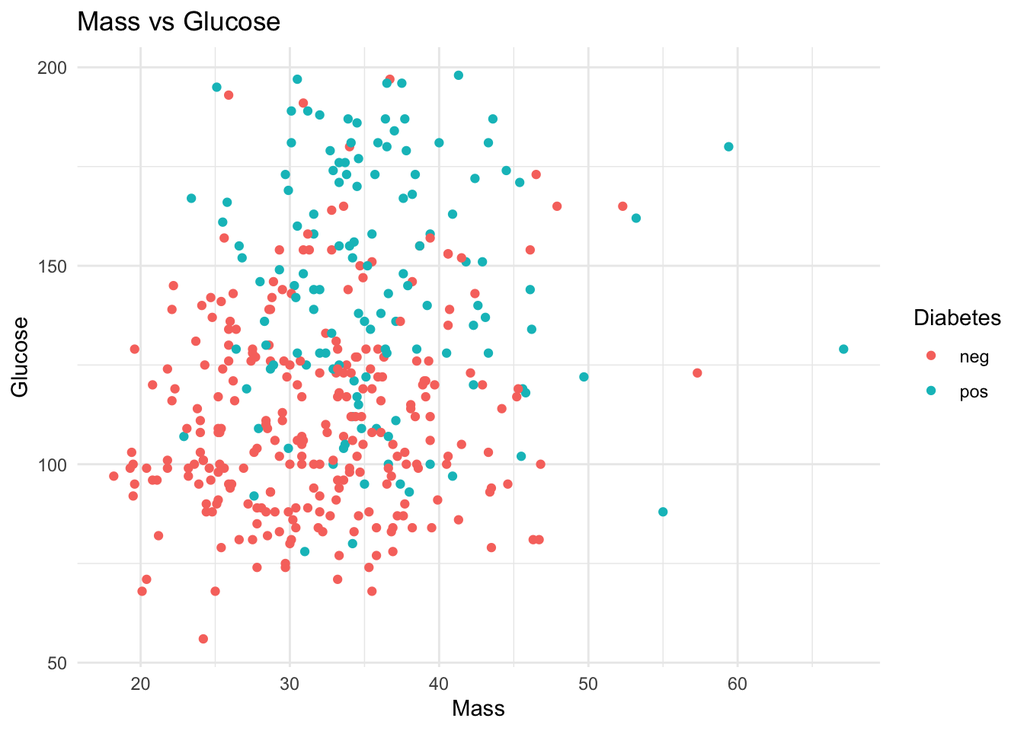

```r
complete.pimas |> ggplot(aes(mass, glucose, color = diabetes)) +
  geom_point() +
  labs(title = "Mass vs Glucose",
       x = "Mass",
       y = "Glucose",
       color = "Diabetes") +
  theme_minimal()
```

**Linear decision boundaries**

Then add to your plot the decision boundaries for **logistic regression** and **linear SVM** using only the `mass` and `glucose` predictors. (Assume for logistic regression that the decision boundary is determined using a cutoff of 0.5 for the predicted probabilities).

*Hint*: it requires you to figure out the intercept and the slope for the linear relationship between `mass` and `glucose`, assuming a linear relationship: `mass` = $\beta_0$ + $\beta_1$`glucose`

$$\log(\frac{p}{1-p}) = \beta_0 + \beta_1 X_1 + \beta_2 X_2$$
As the decision is set to 0.5 ($p = 0.5)$, it means that $log(\frac{p}{1-p}) = 0$. Therefore, by re-arranging,

$$\beta_2 X_2 = -\beta_0 - \beta_1 X_1$$
$$X_2 = - \frac{\beta_0}{\beta_2} - \frac{\beta_1 X_1}{\beta_2}$$

[figure not shown]

```r
logit.model2 <- glm(diabetes ~ glucose + mass, data = complete.pimas, family = binomial(link = "logit"))

logit.coefs <- coefficients(logit.model2)
logit.slope <- -logit.coefs["glucose"] / logit.coefs["mass"]
logit.intercept <- -logit.coefs["(Intercept)"] / logit.coefs["mass"]

plot(mass ~ glucose, data = complete.pimas, col = cols, pch = 16)
abline(logit.intercept, logit.slope, lwd = 2)
```

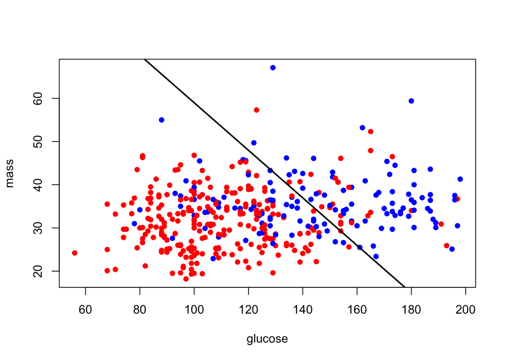

```r
# Using the same parameter search as earlier
svm.model2 <- train(diabetes ~ glucose + mass, data =complete.pimas, method = "svmLinearWeights", scale = FALSE,
                   trControl = trainControl(method = "repeatedcv", repeats = 5))

svm.coefs.linear <- coef(svm.model2$finalModel)
svm.linear.slope <- -svm.coefs.linear["glucose"] / svm.coefs.linear["mass"]
svm.linear.intercept <- -svm.coefs.linear["(Intercept)"] / svm.coefs.linear["mass"]
cols <- ifelse(complete.pimas$diabetes == "pos", "blue", "red")

plot(mass ~ glucose, data = complete.pimas, col = cols, pch = 16)
abline(svm.linear.intercept, svm.linear.slope, lwd = 2)
```

## 2.5 Non-linear boundaries (Take-Home Exercise)

The following graphs illustrate the decision boundaries created by the `kNN` method and the `SVM` with a radial kernel have been implemented on the `pimatrain` training data set.

Comment on the differences observed between the two decision boundaries.

**Graphs**

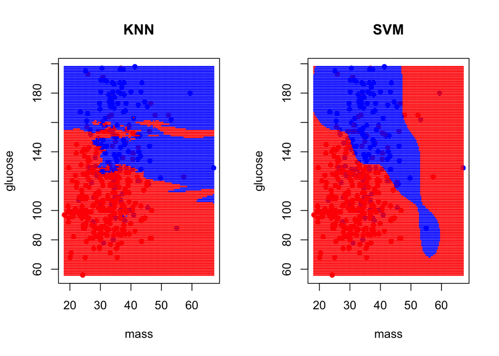

```r
## code is optional but it is more important to interpret
viz.knn.model <- train(diabetes ~ glucose + mass, data = pimatrain, method = "knn",
                       prob = TRUE,
                       trControl = trainControl(method = "repeatedcv", repeats = 5))

# mapping decision boundary
relevant.dat <- complete.pimas %>% dplyr::select(mass, glucose)
grids <- lapply(relevant.dat, function(x) seq(from = min(x), to = max(x), length.out = 128))

viz.dat <- expand.grid(grids)

knn.predictions <- predict(viz.knn.model, viz.dat)

svm.radial.model <- train(diabetes ~ mass + glucose, data = pimatrain,
                          method = "svmRadialWeights",
                          trControl = trainControl(method = "repeatedcv", repeats = 5))
svm.predictions <- predict(svm.radial.model, viz.dat)

par(mfrow = c(1, 2))
plot(glucose ~ mass, data = complete.pimas, col = cols, pch = 16,
     main = "KNN")
points(viz.dat, col = ifelse(knn.predictions == "neg", "red", "blue"), cex = 0.3, pch = 16)
plot(glucose ~ mass, data = complete.pimas, col = cols, pch = 16,
     main = "SVM")
points(viz.dat, col = ifelse(svm.predictions == "neg", "red", "blue"), cex = 0.3, pch = 16)
```

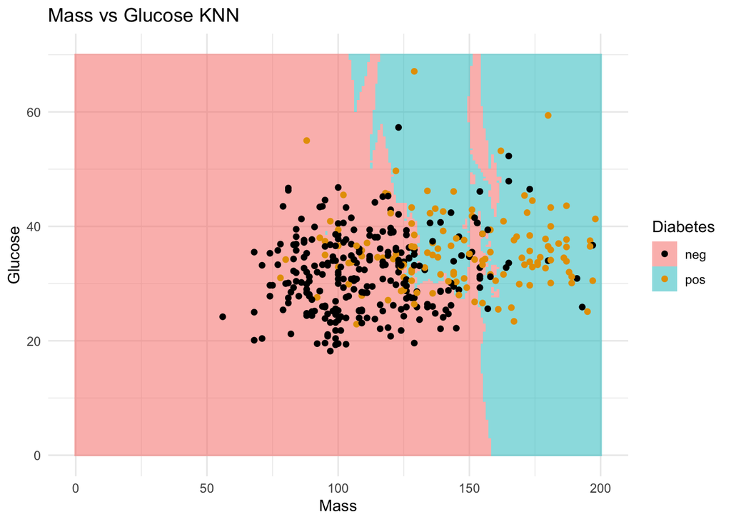

```r
## Alternative code that does the same thing with ggplot
# Extension - we can add in the decision boundaries by creating an additional test set getting the predicted value at every possible pair.

grid.knn <- expand.grid(glucose = seq(0, 200, length.out = 200),
                    mass = seq(0, 70, length.out = 200))
grid.svm <- expand.grid(glucose = seq(0, 200, length.out = 200),
                    mass = seq(0, 70, length.out = 200))

knn.model.viz <- train(diabetes ~ mass + glucose, data = pimatrain, method = "knn", prob = TRUE, trControl = trainControl(method = "repeatedcv", repeats = 5))
svm.model.viz <- train(diabetes ~ mass + glucose, data = pimatrain, method = "svmRadialWeights", trControl = trainControl(method = "repeatedcv", repeats = 5))

grid.knn$diabetes <- predict(knn.model.viz, grid.knn)
grid.svm$diabetes <- predict(svm.model.viz, grid.svm)

complete.pimas |> ggplot(aes(x = glucose, y = mass, fill = diabetes))+
  geom_raster(data = grid.knn, alpha = 0.5) +
  geom_point(aes(color = diabetes)) +
  labs(title = "Mass vs Glucose KNN",
       x = "Mass",
       y = "Glucose",
       color = "Diabetes",
       fill = "Diabetes") +
  theme_minimal()+
  scale_color_colorblind()
```

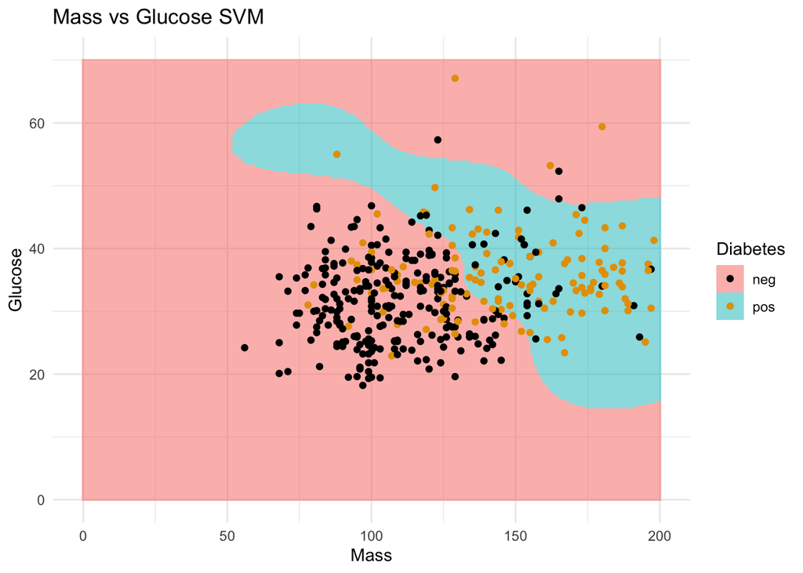

```r
complete.pimas |> ggplot(aes(x = glucose, y = mass, fill = diabetes)) +
  geom_raster(data = grid.svm, alpha = 0.5) +
  geom_point(aes(color = diabetes)) +
  labs(title = "Mass vs Glucose SVM",
       x = "Mass",
       y = "Glucose",
       color = "Diabetes",
       fill = "Diabetes") +
  theme_minimal() +
  scale_color_colorblind() ## add to produce graphs that are color-blind friendly
```

Both generated decision regions are nonlinear and non-parametric.

However, the `kNN` fits is more irregular and has jagged edges. This happens because `kNN` makes predictions based on the local local majority of nearest neighbors, which can lead to highly localized and detailed classification regions.

The SVM boundary slightly smoother and curved.This is because SVM finds an optimal hyperplane (or curved boundary with an RBF kernel) that maximizes the margin between classes.

Unlike kNN, SVM does not depend on local distributions but rather on a global optimization problem.